# US craft beer

Anna Reynolds

16 July 2018

## Craft beer in the US

This weeks #TidyTuesday data set is on craft beer in the US. There are 2 worksheets in an Excel spreadsheet, one with brewery location information and the other contains data on the types of beer made by the breweries.

### Import the data

```r
library(tidyverse)
library(readxl)
library(ggthemes)
library(viridis)
library(hrbrthemes)

beer1 <- readxl::read_excel(sheet = "breweries", 'week15_beers.xlsx')
beer2 <- readxl::read_excel(sheet = "beers", 'week15_beers.xlsx')
head(beer1)
```

```
## # A tibble: 6 x 5
##   count name                      city          state    id
##   <dbl> <chr>                     <chr>         <chr> <dbl>
## 1    1. NorthGate Brewing         Minneapolis   MN       0.
## 2    2. Against the Grain Brewery Louisville    KY       1.
## 3    3. Jack's Abby Craft Lagers  Framingham    MA       2.
## 4    4. Mike Hess Brewing Company San Diego     CA       3.
## 5    5. Fort Point Beer Company   San Francisco CA       4.
## 6    6. COAST Brewing Company     Charleston    SC       5.
```

```r
head(beer2)
```

```
## # A tibble: 6 x 8
##   count    abv   ibu    id name                style     brewery_id ounces
##   <dbl>  <dbl> <dbl> <dbl> <chr>               <chr>          <dbl>  <dbl>
## 1    1. 0.0500    NA 1436. Pub Beer            American~       408.    12.
## 2    2. 0.0660    NA 2265. Devil's Cup         American~       177.    12.
## 3    3. 0.0710    NA 2264. Rise of the Phoenix American~       177.    12.
## 4    4. 0.0900    NA 2263. Sinister            American~       177.    12.
## 5    5. 0.0750    NA 2262. Sex and Candy       American~       177.    12.
## 6    6. 0.0770    NA 2261. Black Exodus        Oatmeal ~       177.    12.
```

The data sets can be joined using the ‘id’ variable in beer1 and ‘brewery_id’ in beer2. The ‘abv’ variable is the alcohol content and ‘ibu’ is a measure of bitterness.

### Which states and cities have the most breweries?

Use the beer1 data set to answer these questions.

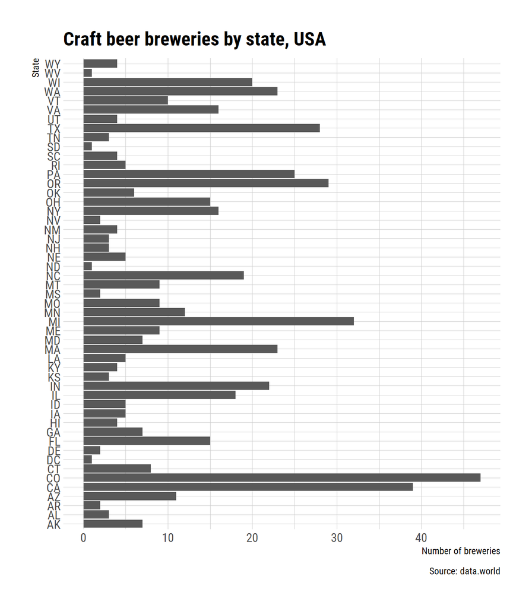

```r
bar1 <- ggplot(beer1, aes(x = state)) + geom_bar(stat = "count") + coord_flip() + theme_ipsum_rc() + labs(x="State", y="Number of breweries",
       title="Craft beer breweries by state, USA",
       caption="Source: data.world")
bar1
```

Colorado and California have the most breweries. It would be good to calculate the number of breweries per capita using state population data.

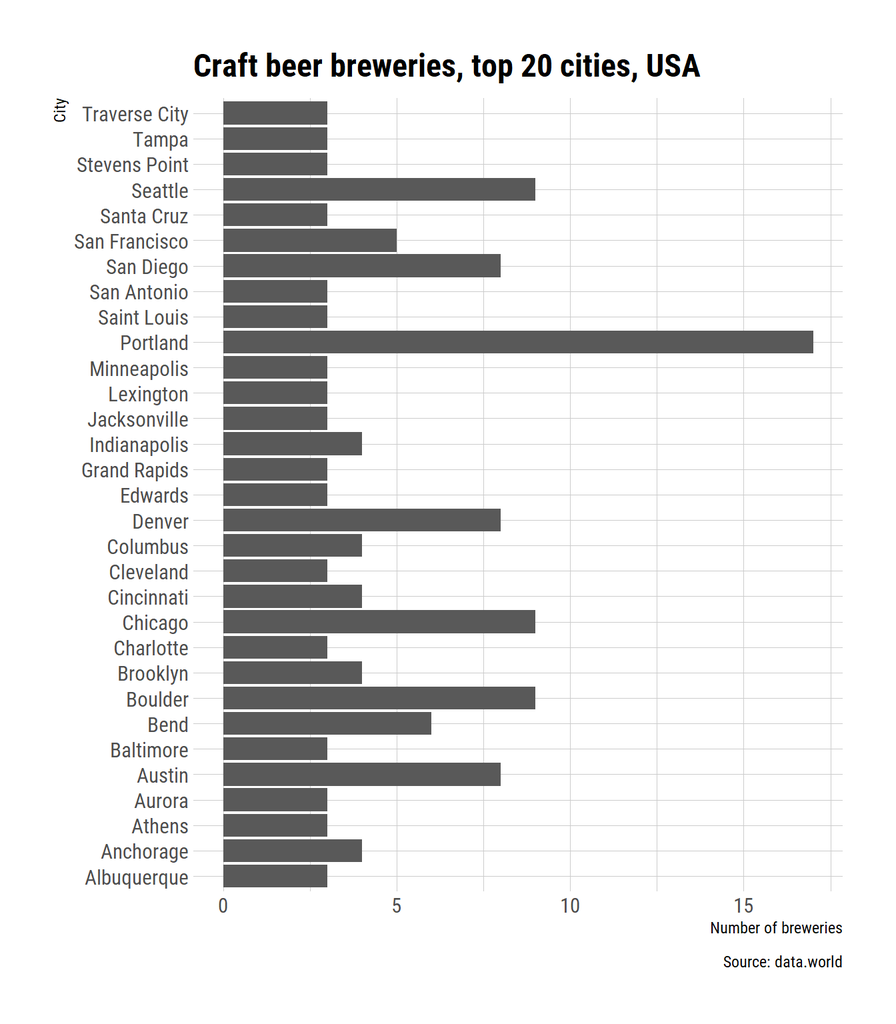

```r
city_20 <- beer1 %>% count(city) %>% top_n(n=20)

bar2 <- ggplot(city_20, aes(x = city, y = n)) + geom_bar(stat = "identity") + coord_flip() +  theme_ipsum_rc() + labs(x="City", y="Number of breweries",
       title="Craft beer breweries, top 20 cities, USA",
       caption="Source: data.world")
bar2
```

Portland in Oregon has the highest number of breweries.

### Is there a relationship between alcohol content and bitterness?

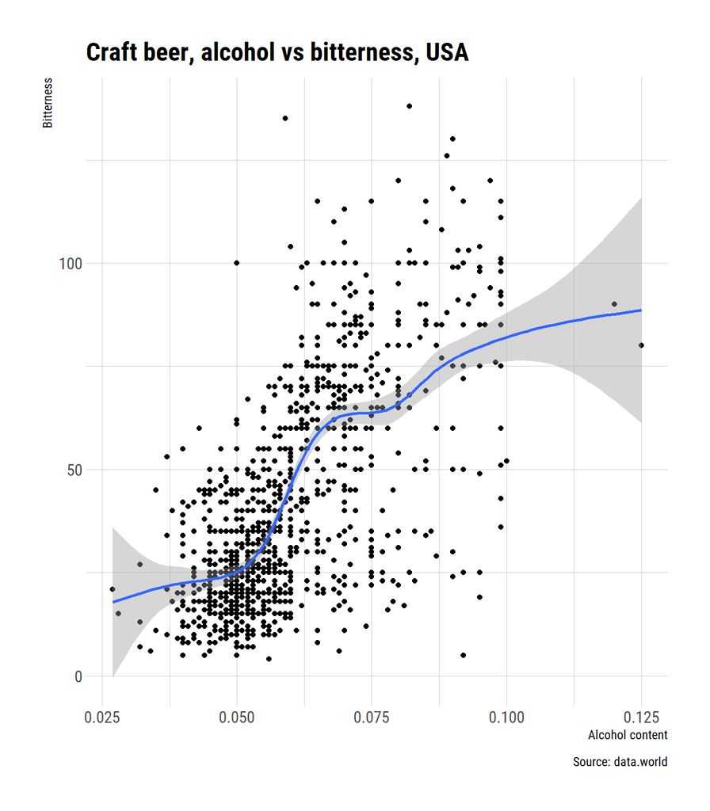

```r
#Remove rows with missing values
beer2clean <- remove_missing(beer2, na.rm = F, vars = names(beer2))
#Make a scatter plot
ggplot(beer2clean, aes(abv, ibu)) + geom_point() + geom_smooth() + theme_ipsum_rc() + labs(x="Alcohol content", y="Bitterness",
       title="Craft beer, alcohol vs bitterness, USA",
       caption="Source: data.world")
```

Bitterness does appear to increase with increasing alcohol content.

#### What does it look like by style of beer?

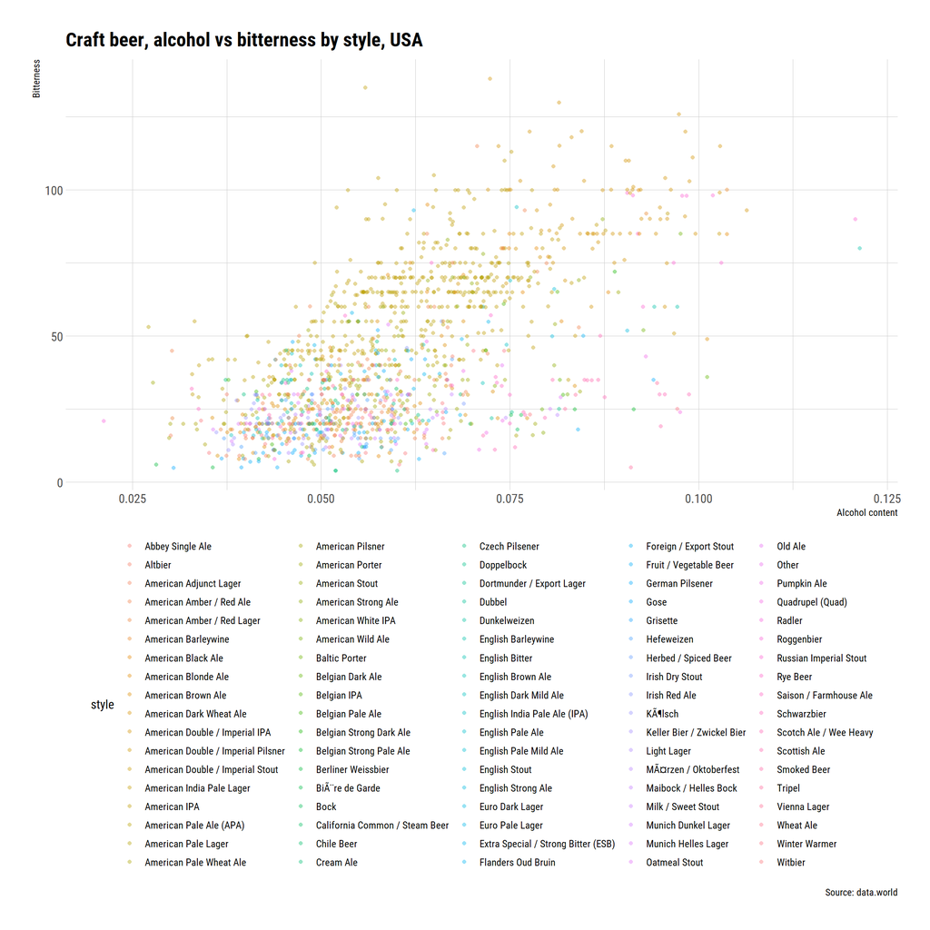

```r
ggplot(beer2clean, aes(x = abv, y = ibu, color=style)) + geom_point(position = position_jitter ( width = 0.01 , height = 0.09 ), alpha = 0.4 , shape = 16 , size = 1.5) + theme_ipsum_rc() + theme(legend.position="bottom") + labs(x="Alcohol content", y="Bitterness",
       title="Craft beer, alcohol vs bitterness by style, USA",
       caption="Source: data.world")
```

The American style beers seem to have higher bitterness, particularly as the alcohol content increases.

#### Filter data to include only styles of beer containing the word American

```r
American <- beer2clean %>% filter(str_detect(style, "American"))
head(American)
```

```
## # A tibble: 6 x 8
##   count    abv   ibu    id name             style        brewery_id ounces
##   <dbl>  <dbl> <dbl> <dbl> <chr>            <chr>             <dbl>  <dbl>
## 1   15. 0.0610   60. 1979. Bitter Bitch     American Pa~       177.  12.0
## 2   22. 0.0990   92. 1036. Lower De Boom    American Ba~       368.   8.40
## 3   25. 0.0440   42.  876. Bitter American  American Pa~       368.  12.0
## 4   29. 0.0700   70.  799. 21st Amendment ~ American IPA       368.  12.0
## 5   30. 0.0700   70.  797. Brew Free! or D~ American IPA       368.  12.0
## 6   31. 0.0700   70.  796. Brew Free! or D~ American IPA       368.  12.0
```

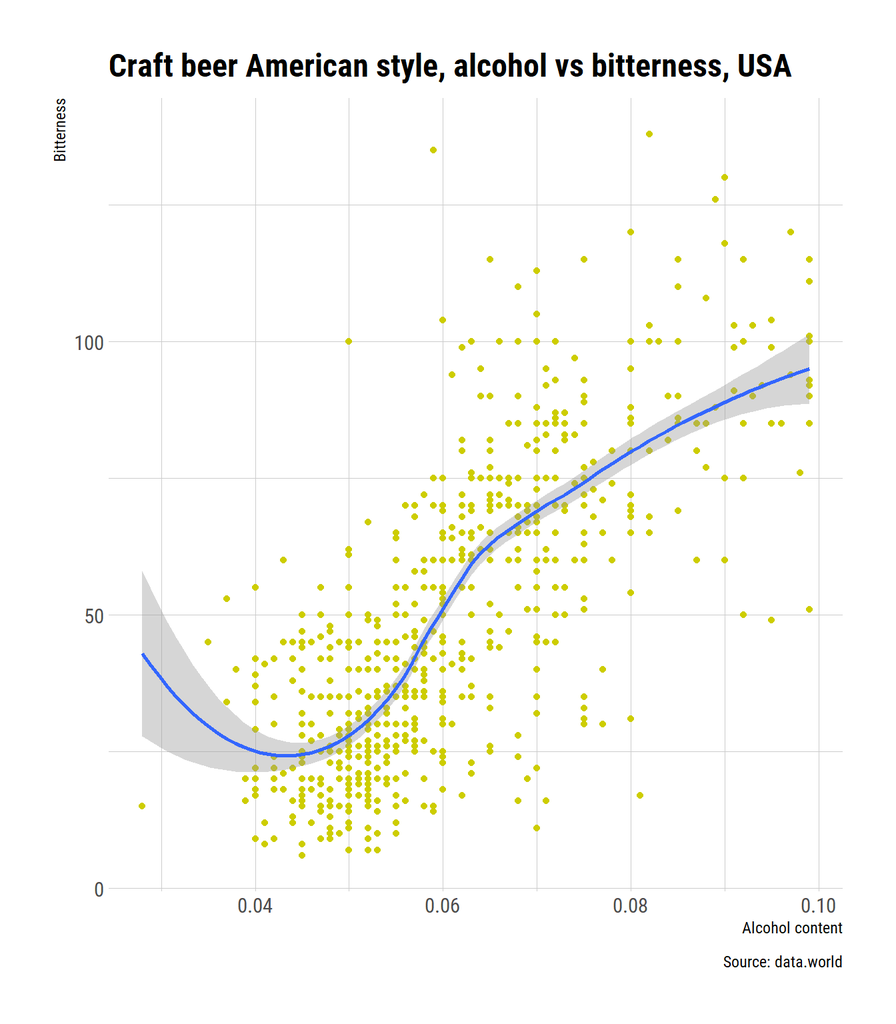

```r
ggplot(American, aes(abv, ibu)) + geom_point(color="yellow3") + geom_smooth() + theme_ipsum_rc() + labs(x="Alcohol content", y="Bitterness",
       title="Craft beer American style, alcohol vs bitterness, USA",
       caption="Source: data.world")
```

#### Filter data to include only styles of beer containing the word English

```r
English <- beer2clean %>% filter(str_detect(style, "English"))
head(English)
```

```
## # A tibble: 6 x 8
##   count    abv   ibu    id name               style      brewery_id ounces
##   <dbl>  <dbl> <dbl> <dbl> <chr>              <chr>           <dbl>  <dbl>
## 1   32. 0.0850   52.  531. Special Edition: ~ English S~       368.    12.
## 2   55. 0.0900   50. 2218. Ironman            English S~        27.    16.
## 3   59. 0.0540   30.  866. British Pale Ale ~ English P~       481.    16.
## 4   60. 0.0540   30.   48. British Pale Ale   English P~       481.    16.
## 5   71. 0.125    80. 2685. London Balling     English B~         1.    16.
## 6   82. 0.0500   20. 2674. The Brown Note     English B~         1.    16.
```

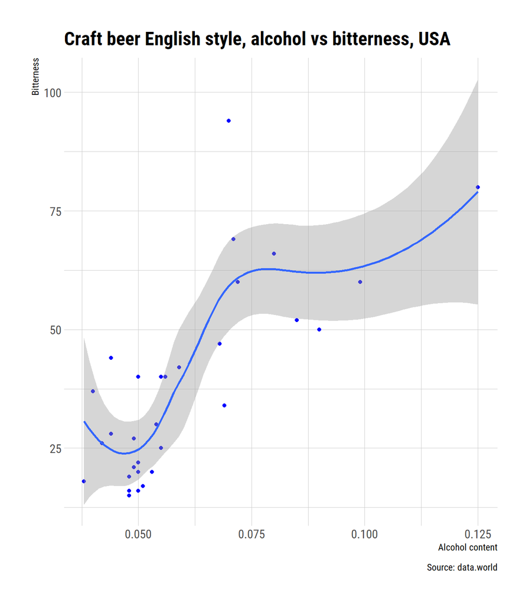

```r
ggplot(English, aes(abv, ibu)) + geom_point(color="blue") + geom_smooth() + theme_ipsum_rc() + labs(x="Alcohol content", y="Bitterness",
       title="Craft beer English style, alcohol vs bitterness, USA",
       caption="Source: data.world")
```